# **Ford GoBikes Analysis**

## **1. Introduction**

Ford GoBike is a bike sharing company in San Fransisco that has provided data for its trips from 2017 to 2020.

**Goal of the project**

1. Find the most common duration for bike rides.
2. Analyze the data and gather insights about the growth in the ridership of the company since 2017.
3. Identify the busiest stations that have maximum bike rides and number of bikes that need to be kept at a station to satisfy demand.
4. Most popular ride days.
5. Busiest time to ride a bike and if there is a relationship with the week day.

## **2. Data Overview**

From the AWS server the data was programmatically downloaded and unzipped.

28 different csv files were retrieved and merged to form a master dataset.

This dataset contains 6 million rows and 14 columns and is about 1.2Gb in size. This data was cleaned for analysis.

The key columns for interest for us are the duration, the start time and end time of the rides. The rides in each year, hour, weekday and the starting and ending stations are also useful for analysis.

```python
import pandas as pd
import numpy as np
import os
import matplotlib.pyplot as plt
import seaborn as sns
import requests
from bs4 import BeautifulSoup
import zipfile
import io
```

```python
# Importing the cleaned file from the local drive
# The data gathering and wrangling parts are in the Udacity Ford GoBike Analysis file

my_folder= r'C:\Users\srini\Udacity\Udacity Ford GoBike'
df= pd.read_csv(os.path.join(my_folder,'master_clean.csv'))
```

## 3. Data Visualization and Analysis

### **3.1 Histogram for ride duration**

We need to see the distribution of the duration column to understand how long people ride.

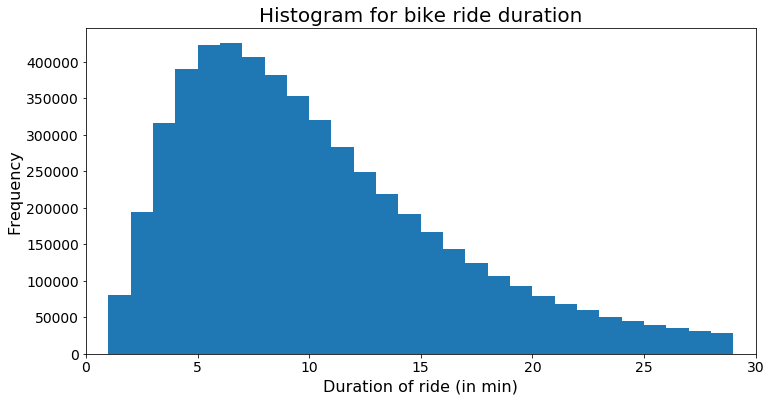

```python
# plotting the histogram for duration_min column
plt.figure(figsize= [12,6])
plt.hist(df.duration_min, bins= np.arange(0,30,1))
plt.xlim((0,30))
plt.xlabel('Duration of ride (in min)',{'fontsize':16} )
plt.ylabel('Frequency',{'fontsize':16} )
plt.title('Histogram for bike ride duration', {'fontsize':20} )
plt.xticks(fontsize=14)
plt.yticks(fontsize=14)
plt.show()
```

The distribution for the duration of bike ride seems to be a right shaped distribution with mode between 5 and 10 min. Hence most of our riders are short distance riders.  
The historgram has been clipped at 30 min as rides above that are very rare.

### **3.2 Busiest Stations**

We need to identify if particular starting station are more busy than others.

```python
# Total days for which we have data for
total_days= 977
```

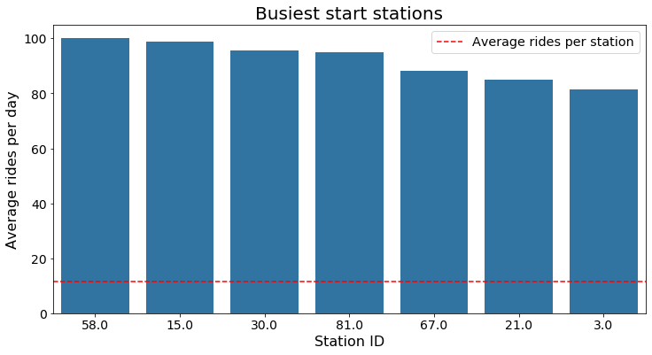

```python
# Calculating the busiest station based on average rides per day
plt.figure(figsize= [12,6])
busy_station= (df.start_station_id.value_counts().head(7))/ 977  # dividing by total days for our data to calculate mean
avg_station_rides = (df.start_station_id.value_counts()/977).mean()

sns.barplot(x= busy_station.index, y= busy_station, color= sns.color_palette()[0], order= busy_station.index )
plt.axhline(avg_station_rides,color='r', linestyle= '--', label= 'Average rides per station')
plt.ylabel('Average rides per day',{'fontsize':16})
plt.xlabel('Station ID',{'fontsize':16})
plt.title('Busiest start stations',{'fontsize':20})
plt.legend(fontsize= 'x-large')
plt.xticks(fontsize=14)
plt.yticks(fontsize=14)
plt.show()
```

The busiest stations have an average of 80 to 100 rides originating from them. These stations have larger number of rides than the average. This shows that several stations have very few rides associated with them. We will explore them more in later multivariate exploration.

### **3.3 Number of rides per week day**

We will explore if there is any relationship between week days (like Monday, Tuesday etc.) and the number of rides.

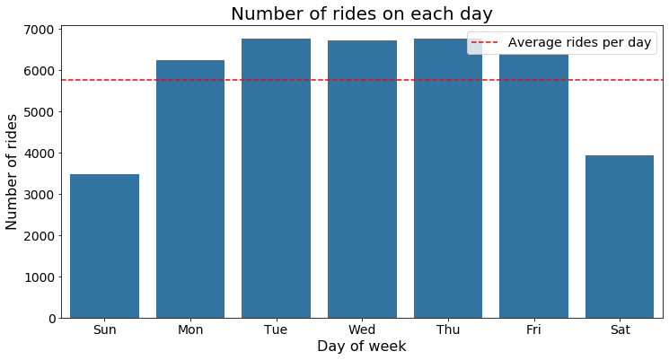

```python
# Grouping the number of rides based on weekday
temp = df.groupby(by='weekday').count()['duration_sec']/ (total_days/7) # Number of times Sunday came in 3 years preiod
avg_ride_per_day = df.shape[0]/ total_days

# Visualizing the number of rides based on weekday
plt.figure(figsize= [12,6])
day_order= 'Sun,Mon,Tue,Wed,Thu,Fri,Sat'.split(',')
sns.barplot(x=temp.index, y=temp.values,color= sns.color_palette()[0],order= day_order)
plt.axhline(avg_ride_per_day,color= 'r',linestyle= '--', label= 'Average rides per day')

plt.title('Number of rides on each day', fontsize= 20)
plt.xlabel('Day of week',{'fontsize':16})
plt.ylabel('Number of rides',{'fontsize':16})
plt.legend(fontsize= 'x-large')
plt.xticks(fontsize=14)
plt.yticks(fontsize=14)
plt.show()
```

### **3.4 Duration of the rides per weekday**

We will try to explore if there is any relationship between week days (like Monday, Tuesday etc.) and the duration of rides.

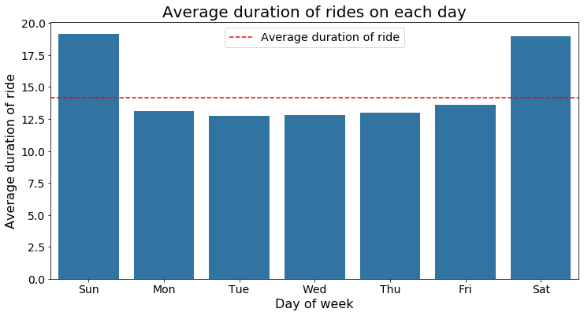

```python
# Visualizing the average duration of rides based on weekday

temp2 = df.groupby(by='weekday').mean()['duration_min']
avg_dur= df.duration_min.mean()

plt.figure(figsize= [12,6])
sns.barplot(x=temp2.index, y=temp2.values,color= sns.color_palette()[0],order= day_order)
plt.axhline(avg_dur, color= 'r',linestyle= '--', label= 'Average duration of ride')
plt.title('Average duration of rides on each day',{'fontsize':20})
plt.xlabel('Day of week',{'fontsize':16})
plt.ylabel('Average duration of ride',{'fontsize':16})
plt.xticks(fontsize=14)
plt.yticks(fontsize=14)
plt.legend(fontsize= 'x-large')
plt.show()
```

Even though the number of rides are less on the weekends, the duration of the rides are on an average 6 min longer on weekends.

### **3.5 Average duration of rides based on the time of day**

In each day there might be different hours where there are different number of rides. We will explore this relationship.

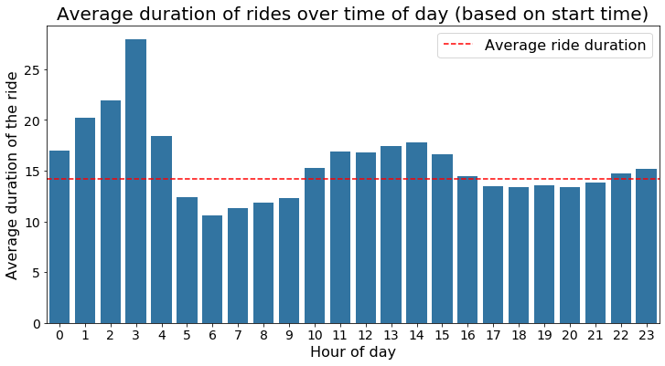

```python
# Visualizing the number of rides based on hourly basis
plt.figure(figsize= [12,6])
temp2 = df.groupby(by='hour').mean()['duration_min']
avg_duration = df.duration_min.mean()

sns.barplot(x=temp2.index, y=temp2.values,color= sns.color_palette()[0])
plt.axhline(avg_duration, color='r', linestyle= '--', label= 'Average ride duration')

plt.title('Average duration of rides over time of day (based on start time)',{'fontsize':20})
plt.xlabel('Hour of day',{'fontsize':16})
plt.ylabel('Average duration of the ride',{'fontsize':16})
plt.xticks(fontsize=14)
plt.yticks(fontsize=14)
plt.legend(fontsize= 16)
plt.show()
```

This shows that on an average the longest duration of cycle rides are between 1am to 4am. This seems counterintuitive. We need to explore the number of rides data to dig deeper.

### **3.6 Average number of rides on a given time of the day**

We need to explore the average number of rides on an hourly basis on a given day.

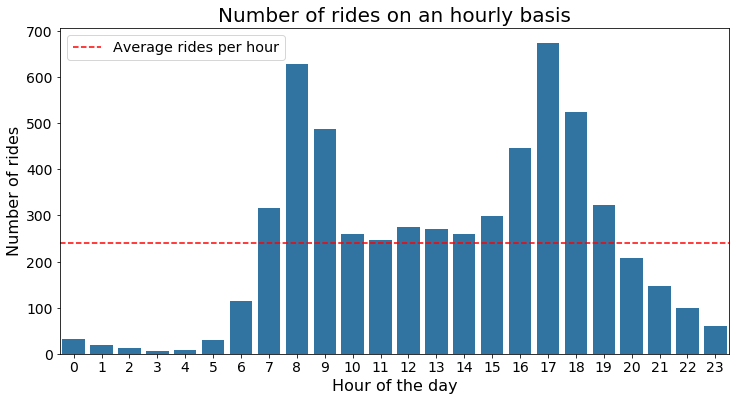

```python
# grouping the data on hourly basis
temp= df.groupby(by='hour').count()['start_time']/ (total_days)
avg_rides_hour = df.shape[0]/(total_days*24)

# Number of rides vs hour of day data
plt.figure(figsize= [12,6])
sns.barplot(x=temp.index, y=temp,color= sns.color_palette()[0])
plt.axhline(avg_rides_hour, color='r', linestyle= '--', label= 'Average rides per hour')

plt.ylabel('Number of rides',{'fontsize':16})
plt.xlabel('Hour of the day',{'fontsize':16})
plt.title('Number of rides on an hourly basis',{'fontsize':20})
plt.legend(fontsize= 'x-large')
plt.xticks(fontsize=14)
plt.yticks(fontsize=14)
plt.show()
```

### **3.7 Number of rides on an hourly basis on each weekday**

Plotting the average number of rides for each hour for each weekday to see if there is any relationship between the 3 features.

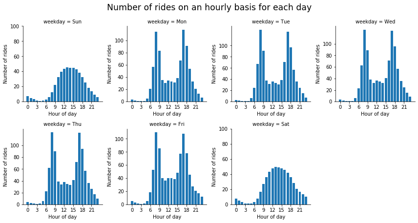

```python
# Seeing the interaction between the number of rides and hour depending on the day of the week
temp2 = (df.groupby(by=['weekday','hour']).count()['duration_min']/total_days).reset_index()

plt.figure(figsize= [12,6])
g= sns.FacetGrid(temp2, col='weekday', col_wrap= 4, col_order= day_order, sharex= False, sharey= False  )
g.map(plt.bar, 'hour','duration_min' )
g.set(xticks=np.arange(0,24,3), ylabel= 'Number of rides', xlabel='Hour of day', yticks= np.arange(0,120,20))

g.fig.suptitle('Number of rides on an hourly basis for each day', y=1.05,fontsize= 'xx-large')
plt.tight_layout()
plt.show(g)
```

This clearly shows the spike in users between 6am and 9am in the morning and 4pm to 6pm in the evening over the weekdays. On weekends there are no such spikes. On weekends the demand is less and the curve is more gentle.

### **3.8 Growth in GoBikes ridership**

Exploring the change in the number of rides from 2017 to 2020 on a monthly basis.

```python
# Merging the year and month columns to find better time series trends
df['year_month']= df.year.map(str)+'-'+df.month.map(str)
df.head(1)
```

|  | duration_sec | start_time | end_time | start_station_id | start_station_name | start_station_latitude | start_station_longitude | end_station_id | end_station_name | end_station_latitude | ... | user_type | bike_share_for_all_trip | rental_access_method | duration_min | year | month | hour | weekday | year_month | ride |
| --- | --- | --- | --- | --- | --- | --- | --- | --- | --- | --- | --- | --- | --- | --- | --- | --- | --- | --- | --- | --- | --- |
| 0 | 80110 | 2017-12-31 16:57:39.654 | 2018-01-01 15:12:50.245 | 74.0 | Laguna St at Hayes St | 37.776435 | -122.426244 | 43.0 | San Francisco Public Library (Grove St at Hyde... | 37.778768 | ... | Customer | NaN | NaN | 1335.166667 | 2017 | 12 | 16 | Sun | 2017-12 | 1 |

1 rows × 22 columns

```python
# Merging the year and month columns for easier analysis
df['year_month']= pd.to_datetime(df['year_month'], format='%Y-%m').dt.strftime('%Y-%m')
```

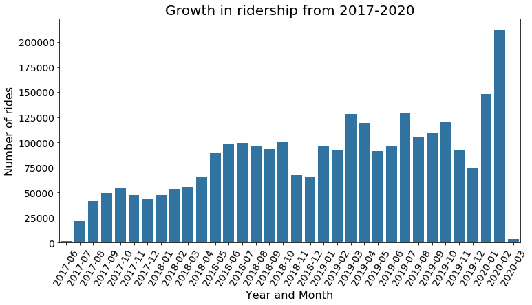

```python
# change in the number of rides from 2017 to 2020 on a monthly basis.
temp = df.groupby(by=['year_month', 'user_type']).count()['start_time'].reset_index()
temp.head()

# Visualizing the growth in rides on a monthly basis
plt.figure(figsize= [12,6])
sns.barplot(x= temp['year_month'], y= temp.start_time, color= sns.color_palette()[0], ci=None)

plt.xticks(rotation= 60)
plt.ylabel('Number of rides',{'fontsize':16})
plt.xlabel('Year and Month',{'fontsize':16})
plt.title('Growth in ridership from 2017-2020',{'fontsize':20})
plt.xticks(fontsize=14)
plt.yticks(fontsize=14)
plt.show()
```

This shows an incresing trend for the bike rides from 2017 onwards. Feb 2020 shows a remarkable spurt in growth in the number of rides.

### **3.9 Growth in GoBike ridership based on type of user**

We need to explore if there is a particular category of the user that has grown more over time.

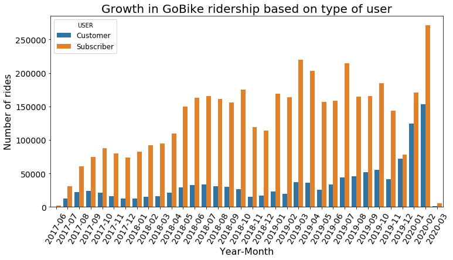

```python
# Visualizing the growth in rides on a monthly basis split by user type
plt.figure(figsize= [12,6])
sns.barplot(x= temp['year_month'], y= temp.start_time, hue= temp['user_type'])
plt.xticks(rotation= 60,fontsize=14)
plt.yticks(fontsize=14)
plt.xlabel('Year-Month',{'fontsize':16})
plt.ylabel('Number of rides',{'fontsize':16})
plt.legend(title='USER',fontsize= 'large')
plt.title('Growth in GoBike ridership based on type of user',{'fontsize':20})
plt.show()
```

From the above graph one can see that the growth in subscriber is much more prominent compared to the growth in customer user type.The growth in subscriber base has grown from 100,000 to 250,000 in less than 2 years.

### **3.10 Growth in ridership based on rental access method**

We need to explore the growth in rental access methods over time. There is lot of missing data and the data is available only since June 2019.

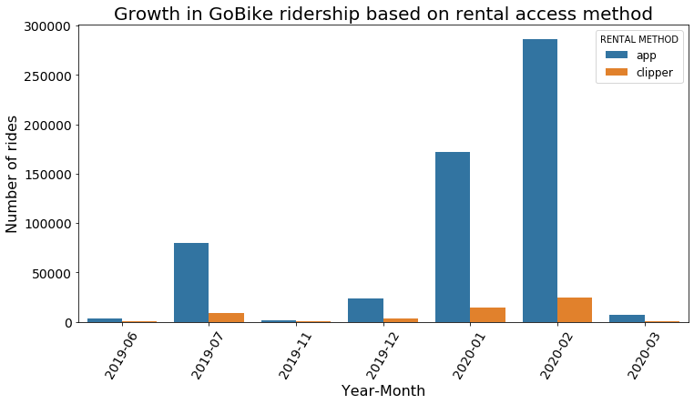

```python
# Visualizing the growth in rides on a monthly basis split by rental access method
temp = df.groupby(by=['year_month', 'rental_access_method']).count()['start_time'].reset_index()
temp.head()

plt.figure(figsize= [12,6])
sns.barplot(x= temp['year_month'], y= temp.start_time, hue= temp['rental_access_method'])
plt.xticks(rotation= 60,fontsize=14)
plt.ylabel('Number of rides',{'fontsize':16})
plt.xlabel('Year-Month',{'fontsize':16})
plt.legend( title='RENTAL METHOD', fontsize='large' )
plt.title('Growth in GoBike ridership based on rental access method',{'fontsize':20})
plt.yticks(fontsize=14)
plt.show()
```

### **4.12 Heatmap depicting the busy hours for each station**

We need to explore which stations are the busiest and at what time. This will help us to understand how many bikes should be kept in each station so that the customer can be served properly.

```python
# Counting the average rides each hour from each station
df_pivot = df.pivot_table(values='ride', index='start_station_id', columns= 'hour', aggfunc=np.sum)/ (total_days)
```

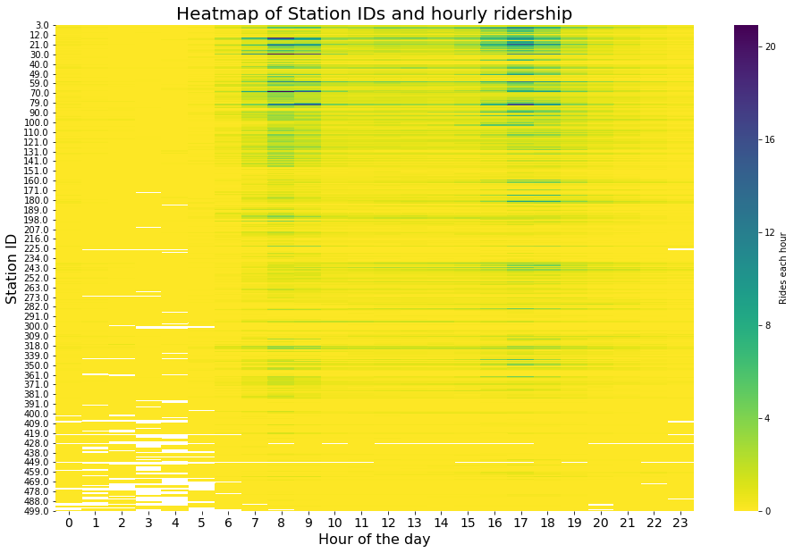

```python
# Plotting a heatmap that shows which stations are busy at which hour
# Since there are 450+ unique station ids, the heatmap wont be a good fit to identify each station
plt.figure(figsize=[16,10])
sns.heatmap(df_pivot, vmin=0, cmap= 'viridis_r', cbar_kws={'label':'Rides each hour'})
plt.title('Heatmap of Station IDs and hourly ridership',{'fontsize':20})
plt.xlabel('Hour of the day',{'fontsize':16})
plt.ylabel('Station ID',{'fontsize':16})
plt.xticks(fontsize=14)
plt.show()
```

Based on the above heatmap we can see that not all stations are equally busy during the weekdays. To ensure maximum revenue we need to make sure that those particular stations always have sufficient number of bikes during the busy time hours.

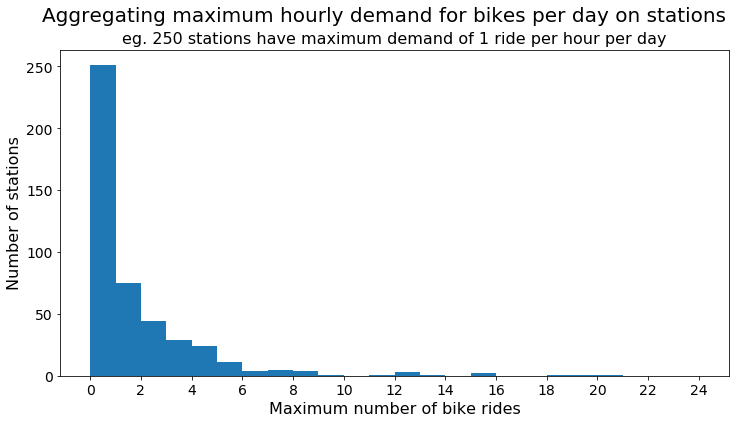

```python
# Summarizing the above heatmap to find how many stations have have how  much of an hourly demand for the bikes
plt.figure(figsize= [12,6])

plt.hist(df_pivot.max(axis=1), bins= np.arange(0,25,1))
plt.xticks(np.arange(0,25,2), np.arange(0,25,2))
plt.xlabel('Maximum number of bike rides',fontsize=16)
plt.ylabel('Number of stations',fontsize=16)
plt.title('eg. 250 stations have maximum demand of 1 ride per hour per day',fontsize=16 )
plt.suptitle('Aggregating maximum hourly demand for bikes per day on stations',fontsize=20)
plt.xticks(fontsize=14)
plt.yticks(fontsize=14)
plt.show()
```

## **4. Conclusion**

The analysis has identified stations and their corresponding peak demand for bikes on an hourly basis. Moreover following conclusions were drawn from the presentation-